# Project 5 - Sheshank

# 8. Pipeline the process

```python
#######################################################################
###### STAGE 8 ########################################################
#######################################################################
```

```
0.9299363057324841
```

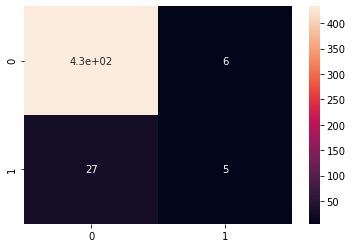

```python
#In this cell we only execute one single pipe, and multimodal pipe demonstration in
#the next cell.
#We choose the same model of Logistic Regression here so that we get an opportunity to check and compare it
#against the different kinds of of synthetic data modeling of over and undersampling mechanism.
#
########################################################################
from sklearn.pipeline import Pipeline
from sklearn.linear_model import LogisticRegression
from sklearn import metrics
#########################################################################
# We Choose
pipeline = Pipeline([('scl', StandardScaler()), ('pca', PCA(n_components=48)), ('clf', LogisticRegression(random_state=1))])
pipeline.fit(X_train,y_train)
y_predict=pipeline.predict(X_test)
print(pipeline.score(X_test, y_test))
########################################################################
sns.heatmap(metrics.confusion_matrix(y_test, y_predict),annot=True)
########################################################################
#

#Here we are setting up the data for a grand scale of pipeline combinations but is not being executed here.
#Sample explanation and big piplines are demonstrated with example next but
#computational complexities prompt no direct execution.
#
#####################################################################
######################################################################
#Scaler=[StandardScaler,zscore,MinMaxScaler]
#Feature_method=[PCA,SMOTE] #More can be added in this
#Models_available=[LogisticRegression,NaiveBayes,KNN,support_vector,decision_tree,bagging,adaboost,gradientboost,MLPC,random_forest,NuSVC]
#Search_Params=[gs,randomCV] # More can be added here too.
##################################################################
##################################################################
#Now, in this steps columns, we can fill with all kinds of imputations, modifications and modified version of each
#and check out how they are respondent.
#pipes_collection=[]
#steps=[]
#########################################################################
#for scl in Scaler:
#    for feature in Feature_method:
#        for Models in Models_available:
#            steps.append(("scl",scl),("features",feature),(str(Models),Models))
#    pipes_collection.append(steps)
#    steps=[]
########################################################################

#####################################################################
# Will can develop various other combinations using the grand pipeline above,
#but we will stick to just one cross validator, one scalar and one feature method
#
#################################################################
#pp_line.fit(X_train,y_train)
```

Let us now define a prototype function that can be extended to do everything about trying and fitting different models.

Our approach is to develop several pipelines for each model, and depending on which model is better than the rest, we will choose that particular model, and subject it to Hyperparameters tuning and find out the best suiting parameters, because parameters can only make model better upon its already existing best parameters, but a model doesn't magically start functioning excellently just by parameter tuning. If so, then that particular model might be biased or some kind of resonance in that range.

**Please Note** : Due to time constraints, and also due to computational constraints unable to include sampling and synthetic data generation methods are not included, because they couldn't be tested in time

```python
# This is a demonstration pipeline, but the original pipelines i.e. pipes_collection will not be used.
###############################################################
from sklearn.pipeline import make_pipeline
#############################################################
#############################################################
pipes=[]
for model in choice_models:
    pipes.append(make_pipeline(StandardScaler(),PCA(n_components=42),Models_list[model]))
##########################################################
#Once our threads (little pipes) are ready here, we pass the list as it is to the function we
#generated previous that is built to deal with multiple models.
```

```python
final=mf(complete_df_models(X_train,y_train,X_test,y_test,Models_list=pipes))

#Make it a little bit more clear

final["Model"]=choice_models
final
```

```
Time taken = 9.4060800075531 seconds
```

|  | Model | Train_score | Test_score | Accuracy | Recall | ROC_AUC | TP | FP | FN | TN | Precision | f1_score |
| --- | --- | --- | --- | --- | --- | --- | --- | --- | --- | --- | --- | --- |
| 0 | KNN | 0.945255 | 0.929936 | 0.929936 | 0.03125 | 0.513347 | 437 | 2 | 31 | 1 | 0.995444 | 0.060598 |
| 1 | random_forest | 0.996350 | 0.934183 | 0.934183 | 0.06250 | 0.530111 | 438 | 1 | 30 | 2 | 0.997722 | 0.117631 |
| 2 | NaiveBayes | 0.906934 | 0.908705 | 0.908705 | 0.18750 | 0.574388 | 422 | 17 | 26 | 6 | 0.961276 | 0.313794 |

**Getting the Best Parameters for Selected Model**

If we are having a conflict on which model to choose, we can use the Cross-validation techniques and check the score, and perhaps hope that a little parameter tuning is going to put one model above the other. If so, then make that informed decision. But, remember only go for it, if you can't decide which model is the best.

In the below function, once you get those best parameters, you can individually see the score they make. Based on that we can make decisions.

```python
#######################################################################
# run randomized search
samples = 100  # number of random samples
randomCV = RandomizedSearchCV(pipes[1][-1], param_distributions=parameters["random_forest"], n_iter=samples) #default cv = 3
randomCV.fit(X_train, y_train)
param_best=randomCV.best_params_
######################################################################
#
#The same as above, but now it is done in a more automated way, as a function.
# We can take the input from these the best parameters for each thread and decide which pipe is the best.
# Beware : This only comes to proper help if you are unable to decide which model to use.
#
#######################################################################
#######################################################################
def finding_and_set_best_params(X_train,y_train,pipe,param):
    #########################################################
    from sklearn.model_selection import RandomizedSearchCV
    #########################################################
    samples = 10  # number of random samples - Can increase randomly for accuracy
    best_param={}
    for each_pipe in pipe:
        k=RandomizedSearchCV(each_pipe, param_distributions=param[each_pipe[-1]],n_iter=samples) #default cv = 3
        k.fit(X_train,y_train)
        best=k.best_params_
        best_param.update({each_pipe:best})
        pipe.set_params(**param_best)
        k=o
    return pipe,best_param # This returns the best parameters for each thread.
#######################################################################
#######################################################################
```

**Notes and Observations** :

Rest of all the ideas, thoughts and suggestions and thrown here and there throughout this notebook. Please kindly consider them as suggestions.

Here, I choose to go with Random Forest algorithmic model.

After we get our final model of choice, we have to finally test our model rigorously so that we can generate some confidence level and statement about our model.

That is done using Bootstrapping. The Model parameters are mentioned as the Confidence Interval of the model and the Confidence level of the model.

Note : The Code below is from one of the solution sets. It is perfect and needn't any kind of modification. Credit where it is due.

```python
param_best
```

```
{'criterion': 'gini',
 'max_depth': None,
 'max_features': 10,
 'min_samples_leaf': 3,
 'min_samples_split': 7,
 'n_estimators': 41}
```

```python
pipes[1][-1].set_params(**param_best)
#Initializing our model for finial pickling and boot strapping.
```

```
RandomForestClassifier(max_features=10, min_samples_leaf=3, min_samples_split=7,
                       n_estimators=41, random_state=1)
```

**Please Note** :

Here in this threads that are constructed above into a pipe are supplied as a pipe to this function here and that returns the best parameters as well as modified pipe. That will help us take informed decisions on whether to choose the model because it has been improvised on the present set or should we choose based on initial fitting.

If we don't want to automatically tune the model, we can ignore that return variable.